# City of San Antonio’s 311 Service.

## Data is here: https://data.sanantonio.gov/dataset/service-calls.

# **The objective:**

This report provides a snapshot of the 311 service requests received by the City of San Antonio. The data highlights the various types of requests received, response times, and the departments involved in providing services to residents.

# **The Outlines:**

- Cleaning Data
- Data Analysis and insights
- Geospatial analysis
- ML models

# **Dataset:**

311 Service Calls: 311 Customer Service connects citizens with specially-trained customer service representatives ready to assist and facilitate City services including animals, potholes, solid waste collection, property maintenance, downed trees, etc. See more Online Service Requests at www.sanantonio.gov/311.

```python
from google.colab import drive,userdata
drive.mount('/content/drive/',force_remount=True)
```

```python
!pip install mapclassify
!pip install numpy>1.24.1
!pip install scipy

import pandas as pd
import seaborn as sns
import matplotlib.pyplot as plt
import numpy as np
from zipfile import ZipFile
from shapely.geometry import Point
import geopandas as gpd
import folium
import mapclassify
from folium.plugins import MarkerCluster,HeatMap
import plotly.express as px
import plotly.graph_objects as go
from plotly.subplots import make_subplots


plt.rcParams['figure.figsize'] = (10, 7)
sns.set_theme(font_scale=1.5, style='whitegrid', palette='bright')
```

```python
service_file="/content/drive/MyDrive/SanAntonioCity311/all_services_calls.csv"
dic_file="/content/drive/MyDrive/SanAntonioCity311/datadictionary-311.xlsx"
```

```python
# dataset Descriptions
dict_data = pd.read_excel(dic_file, skiprows=[0,1],index_col='Field #')
dict_data
```

| Field # | Field Name | Description | Data Type | Comment |
| --- | --- | --- | --- | --- |
| 1 | _id | The number for the respective case on the spre... | Text | NaN |
| 2 | CATEGORY | This general category was developed to place 3... | Text | There are seven categories with one or more d... |
| 3 | CASEID | The unique case reference number is assigned b... | 10 numeric characters | NaN |
| 4 | OPENEDDATETIME | The date and time that a case was submitted. | mm/dd/yyyy hh:mm:ss AM/PM | NaN |
| 5 | SLA_Date | Every service request type has a due date assi... | mm/dd/yyyy hh:mm:ss AM/PM | NaN |
| 6 | CLOSEDDATETIME | The date and time that the case/request was wa... | mm/dd/yyyy hh:mm:ss AM/PM | If there is no closed date, the case is still ... |
| 7 | Late (Yes/No) | This indicates whether the case has surpassed ... | YES/NO | NaN |
| 8 | Dept | The City department to whom the case is assigned. | Text | NaN |
| 9 | REASONNAME | The department division within the City deaprt... | Text | The 311 Customer Service Office facilitates se... |
| 10 | TYPENAME | The service request type name for the issue be... | Text | NaN |
| 11 | CaseStatus | The status of a case which is either open or c... | Open/Closed | NaN |
| 12 | SOURCEID | The source id is the method of input from whic... | Text | Souces for service requests/cases include Cons... |
| 13 | OBJECTDESC | The location address or intersection for the r... | Text | The |
| 14 | Council District | The Council District number from where the iss... | Numeric (0-10) | The City of San Antonio has ten council distri... |
| 15 | XCOORD | The X coordinate of the case reported. | 8 numeric character | NaN |
| 16 | YCOORD | The Y coordinate of the case reported. | 8 numeric character | NaN |
| 17 | Report Starting Date | The start date range for the case open date fo... | mm/dd/yyyy | The report starting date is 365 days prior to ... |
| 18 | Report Ending Date | The end date range for the case open date for ... | mm/dd/yyyy | The report ending date is the date the report ... |

```python
services_all = pd.read_csv(service_file)
services_all.drop(columns=['_id'],inplace=True)
services_all.shape
columns_to_convert = ['OPENEDDATETIME', 'SLA_Date', 'CLOSEDDATETIME']
services_all[columns_to_convert] = services_all[columns_to_convert].apply(pd.to_datetime)
services_all.rename(columns={'Council District':'Council_District','Late (Yes/No)':'Late'},inplace=True)
services_all.shape
```

```
(606061, 17)
```

```python
services_all.head(2)
```

|  | Category | CASEID | OPENEDDATETIME | SLA_Date | CLOSEDDATETIME | Late | Dept | REASONNAME | TYPENAME | CaseStatus | SourceID | OBJECTDESC | Council_District | XCOORD | YCOORD | Report Starting Date | Report Ending Date |
| --- | --- | --- | --- | --- | --- | --- | --- | --- | --- | --- | --- | --- | --- | --- | --- | --- | --- |
| 0 | Traffic Signals and Signs | 1014001765 | 2017-11-03 | 2021-09-22 | 2023-03-16 | YES | Public Works | Signals | Signal Timing Modification By Engineer | Closed | Constituent Call | PATRON and POTEET JDTN FY | 4 | 2111686.0 | 13670865.0 | 3/2/2023 | 3/2/2024 |
| 1 | Solid Waste Services | 1014303843 | 2018-03-07 | 2018-03-16 | 2023-03-08 | YES | Solid Waste Management | Waste Collection | Additional Cart Request | Closed | Constituent Call | 1819 POPLAR ST W, San Antonio, 78207 | 1 | 2121442.0 | 13708006.0 | 3/2/2023 | 3/2/2024 |

```python
#check if ther is any duplicated rows/ no
services_all.duplicated().sum()
```

```
0
```

```python
# Each line is individual case
services_all.CASEID.duplicated().sum()
```

```
0
```

```python
services_all.info()
```

```
<class 'pandas.core.frame.DataFrame'>
RangeIndex: 606061 entries, 0 to 606060
Data columns (total 17 columns):
 #   Column                Non-Null Count   Dtype
---  ------                --------------   -----
 0   Category              606061 non-null  object
 1   CASEID                606061 non-null  int64
 2   OPENEDDATETIME        606061 non-null  datetime64[ns]
 3   SLA_Date              605696 non-null  datetime64[ns]
 4   CLOSEDDATETIME        548841 non-null  datetime64[ns]
 5   Late                  606061 non-null  object
 6   Dept                  606061 non-null  object
 7   REASONNAME            606061 non-null  object
 8   TYPENAME              606061 non-null  object
 9   CaseStatus            606061 non-null  object
 10  SourceID              606061 non-null  object
 11  OBJECTDESC            606061 non-null  object
 12  Council_District      606061 non-null  int64
 13  XCOORD                606052 non-null  float64
 14  YCOORD                606052 non-null  float64
 15  Report Starting Date  606061 non-null  object
 16  Report Ending Date    606061 non-null  object
dtypes: datetime64[ns](3), float64(2), int64(2), object(10)
memory usage: 78.6+ MB
```

```python
services_all.CLOSEDDATETIME.describe()
```

```
count                  548841
unique                    367
top       2023-08-07 00:00:00
freq                     3837
first     2023-03-02 00:00:00
last      2024-03-02 00:00:00
Name: CLOSEDDATETIME, dtype: object
```

```python
# check missing values
services_all.isna().sum().sort_values(ascending=False)
```

```
CLOSEDDATETIME          57220
SLA_Date                  365
YCOORD                      9
XCOORD                      9
Category                    0
SourceID                    0
Report Starting Date        0
Council_District            0
OBJECTDESC                  0
TYPENAME                    0
CaseStatus                  0
CASEID                      0
REASONNAME                  0
Dept                        0
Late                        0
OPENEDDATETIME              0
Report Ending Date          0
dtype: int64
```

```python
# there is no district 0 so we replace with with nan to be droped.
services_all['Council_District'].replace(0,np.nan,inplace=True)
```

```python
# drop the nan values form SLA data and the Coordinates
services_all_dropna=services_all.dropna(subset=['SLA_Date','XCOORD','YCOORD','Council_District'])
services_all_dropna.shape
```

```
(601591, 17)
```

```python
services_all_dropna.select_dtypes('object').nunique().sort_values(ascending=True)
```

```
Report Starting Date         1
Report Ending Date           1
Late                         2
CaseStatus                   2
SourceID                     3
Dept                         9
Category                    11
REASONNAME                  26
TYPENAME                   260
OBJECTDESC              231202
dtype: int64
```

```python
# shows all the unique values in the object data columns
categories=services_all_dropna.select_dtypes('object').nunique().sort_values(ascending=True)[:5].index
services_all_dropna[categories].apply(lambda x:x.unique(),axis=0)
```

```
Report Starting Date                                           [3/2/2023]
Report Ending Date                                             [3/2/2024]
Late                                                            [YES, NO]
CaseStatus                                                 [Closed, Open]
SourceID                [Constituent Call, 311 Mobile App, Code Proact...
dtype: object
```

```python
services_all_dropna=services_all_dropna.drop(columns=['Report Starting Date','Report Ending Date'])
```

```python
services_all_dropna.describe(include='object')
```

|  | Category | Late | Dept | REASONNAME | TYPENAME | CaseStatus | SourceID | OBJECTDESC |
| --- | --- | --- | --- | --- | --- | --- | --- | --- |
| count | 601591 | 601591 | 601591 | 601591 | 601591 | 601591 | 601591 | 601591 |
| unique | 11 | 2 | 9 | 26 | 260 | 2 | 3 | 231202 |
| top | Property Maintenance | NO | Development Services | Code Enforcement | Overgrown Yard/Trash | Closed | Constituent Call | Woodlawn Lake Park, 1103 CINCINNATI AVE, SAN ... |
| freq | 197245 | 483749 | 197974 | 197245 | 64163 | 544698 | 445063 | 755 |

```python
# obj to category
object_columns = ['Category','Dept','CaseStatus','SourceID','Late','Council_District']
#services_all_dropna[object_columns] = services_all_dropna[object_columns].astype('category')
```

# **Exploratory Data Analysis:**

```python
df=services_all_dropna.copy()
print(f"the total number of cases is {df.shape[0]}")
```

```
the total number of cases is 601591
```

```python
[print(col,'\n',df[col].value_counts(),'\n\n') for col in object_columns]
```

```
Category
 Property Maintenance         197245
Solid Waste Services         193217
Animals                      117135
Streets & Infrastructure      37583
Traffic Signals and Signs     27936
Parks                         14264
Health & Sanitation            5882
Information                    4969
Dockless Vehicle               2507
Graffiti                        478
Historic Preservation           375
Name: Category, dtype: int64


Dept
 Development Services               197974
Solid Waste Management             195719
Animal Care Services               117382
Public Works                        65759
Parks and Recreation                14834
311                                  4157
Metro Health                         3481
Human Services                       1910
Office of Historic Preservation       375
Name: Dept, dtype: int64


CaseStatus
 Closed    544698
Open       56893
Name: CaseStatus, dtype: int64


SourceID
 Constituent Call        445063
Code Proactive Calls    116934
311 Mobile App           39594
Name: SourceID, dtype: int64


Late
 NO     483749
YES    117842
Name: Late, dtype: int64


Council_District
 5.0     92569
1.0     83895
2.0     82538
3.0     80741
4.0     62874
7.0     55630
6.0     47572
10.0    42728
8.0     26729
9.0     26315
Name: Council_District, dtype: int64
```

```
[None, None, None, None, None, None]
```

```python
def plot_bar_chart(df, y_column, title):
    # Set up the figure and plot
    plt.figure(figsize=(10, 6))
    sns.set(style="whitegrid")
    sns.set_palette("husl")  # Choosing a color palette

    # Sort the data by count
    df_sorted = df[y_column].value_counts().reset_index().rename(columns={'index': y_column, y_column: 'Count'})
    #df_sorted = df_sorted.sort_values(ascending=False)

    # Plot the sorted countplot
    ax=sns.countplot(data=df, x=y_column, order=df_sorted[y_column])
    # Get the total number of data points
    total = len(df[y_column])
    # Loop through each bar in the plot
    for p in ax.patches:
        # Get the height of the bar
        height = p.get_height()
        # Calculate the percentage
        percentage = height / total * 100
        # Annotate the percentage on top of the bar
        ax.annotate(f'{percentage:.2f}%', (p.get_x() + p.get_width() / 2., height), ha='center', va='center', fontsize=10, xytext=(0, 5), textcoords='offset points')

    # Add labels and title
    plt.xlabel(y_column, fontsize=12)
    plt.ylabel('Count', fontsize=12)
    plt.title(title, fontsize=14)
    # Rotate x-axis labels for better readability
    plt.xticks(rotation=30, ha='right', fontsize=10)
    plt.tight_layout()

    # Show the plot
    #plt.savefig('/content/drive/MyDrive/SanAntonioCity311/'+title+'.png')
    plt.show()
```

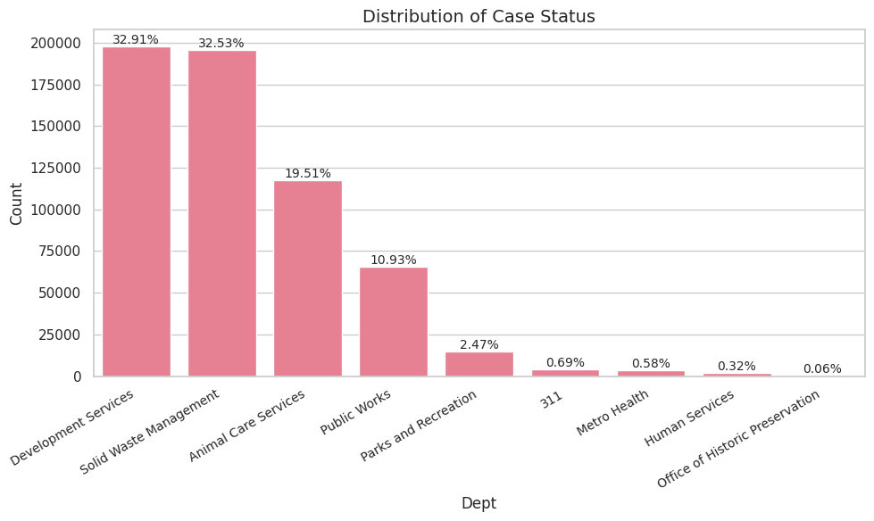

```python
plot_bar_chart(df, 'Dept', 'Distribution of Case Status')
```

The data displays the frequency of service requests by department, revealing notable trends. "Development Services" and "Solid Waste Management" emerge as the most frequently cited departments, indicating significant public engagement with these areas. "Animal Care Services" also garners substantial attention, suggesting a community focus on animal welfare. Conversely, departments such as "Public Works," "Parks and Recreation," and "311" receive fewer requests, potentially indicating lower public interaction or fewer reported issues. Insights gleaned from this data can aid in resource allocation, service optimization, and enhancing public engagement strategies.

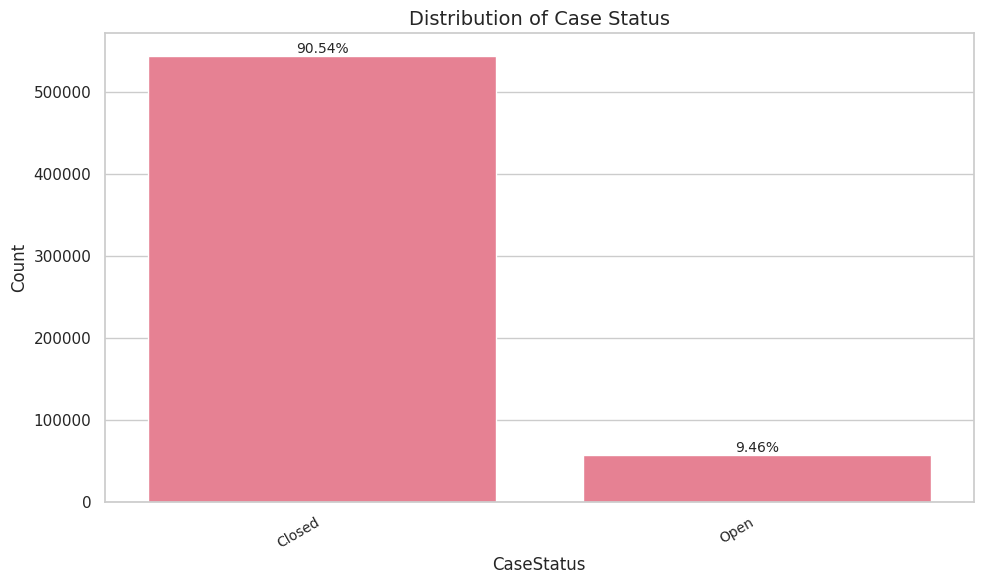

```python
plot_bar_chart(df, 'CaseStatus', 'Distribution of Case Status')
```

The data illustrates the status of cases, categorized as "Closed" and "Open." With a significantly higher count in the "Closed" category compared to "Open," it suggests that the majority of cases have been resolved or completed. However, the presence of "Open" cases highlights ongoing or unresolved issues that may require further attention or action. Monitoring and addressing open cases effectively can help ensure timely resolution and enhance constituent satisfaction with service delivery.

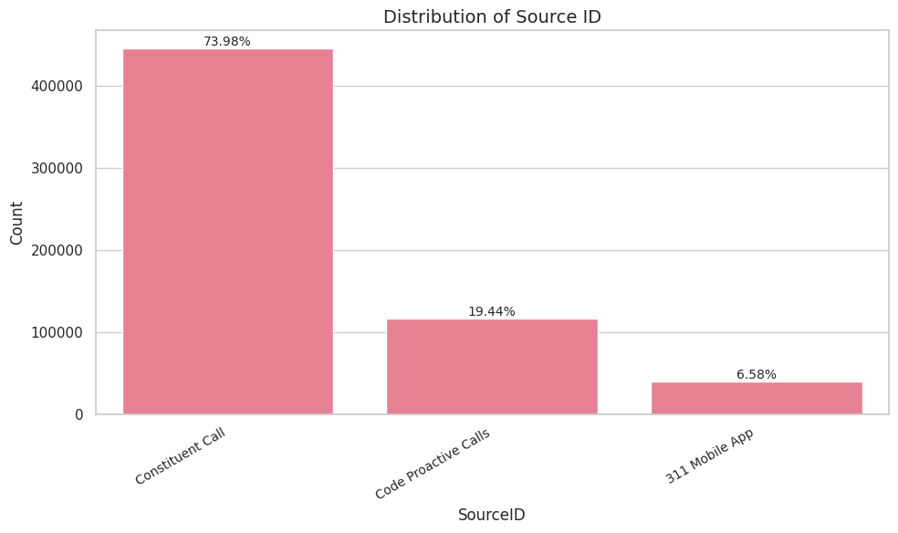

```python
plot_bar_chart(df, 'SourceID', 'Distribution of Source ID')
```

The data provides insights into the sources of service requests, indicating how constituents interact with the system. "Constituent Call" emerges as the primary source, with a significantly higher frequency compared to "Code Proactive Calls" and "311 Mobile App." This suggests that constituents predominantly rely on direct calls to report issues. However, the sizable number of "Code Proactive Calls" highlights proactive efforts by the organization to address issues before they are reported. The relatively lower frequency of requests from the "311 Mobile App" may indicate opportunities for promoting and enhancing mobile app usage among constituents. Overall, understanding request sources is crucial for optimizing communication channels and improving constituent engagement.

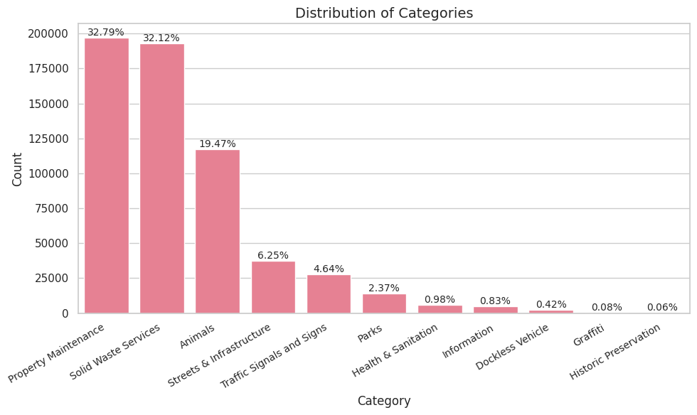

```python
plot_bar_chart(df, 'Category','Distribution of Categories')
```

The data shows the frequency of different service request categories, highlighting the most common issues reported. "Property Maintenance" and "Solid Waste Services" stand out as the most frequent categories, indicating these are major concerns within the community. Other categories, such as "Animals" and "Streets & Infrastructure," also appear frequently but to a lesser extent. This suggests a diverse range of issues being addressed by service providers. The dataset could be used to prioritize resource allocation and identify areas for improvement, particularly in less common categories like "Graffiti" and "Historic Preservation

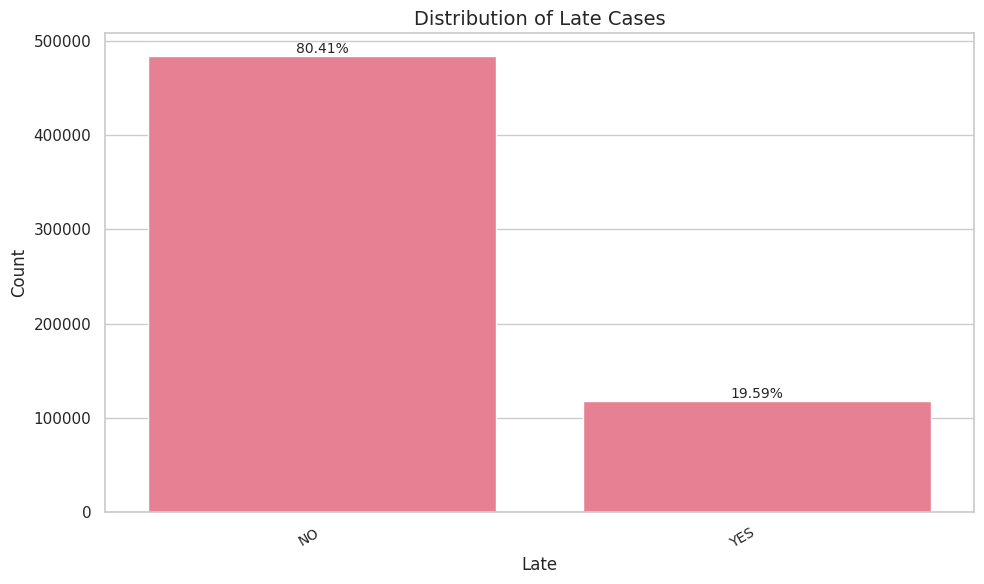

```python
plot_bar_chart(df,'Late','Distribution of Late Cases')
```

The data indicates instances of late processes, categorized as "NO" and "YES." With a significantly higher count in the "NO" category compared to "YES," it suggests that most processes are completed on time. However, the presence of "YES" instances highlights a portion of processes that experience delays. Analyzing the reasons behind these delays and implementing strategies to mitigate them could improve overall process efficiency and timeliness.

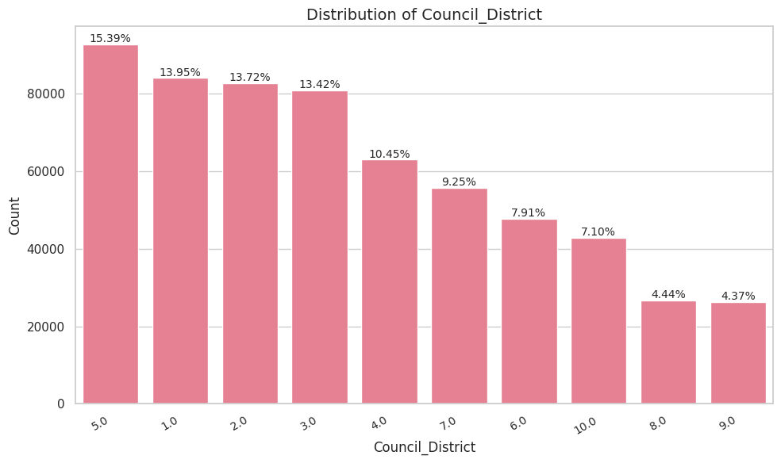

```python
plot_bar_chart(df,'Council_District','Distribution of Council_District')
```

The data represents service requests distributed across different council districts. Districts 5, 1, and 2 have the highest request counts, indicating higher levels of constituent engagement or service needs in these areas. Conversely, districts 8 and 9 have comparatively lower request counts, suggesting potentially lower service demand or fewer reported issues. Understanding these variations can inform resource allocation and prioritize service delivery efforts across different council districts

## Extract the zip code

```python
df.OBJECTDESC.str.extract(r'(\d{5})', expand=True).value_counts(dropna=False)
```

```
NaN      90161
78207    29623
78228    29547
78210    25729
78201    24134
         ...
15909        1
15912        1
15932        1
15942        1
14559        1
Length: 5717, dtype: int64
```

## The interval time

```python
#ind=df[df['CaseStatus']=='Closed'].index
#df_open=df.drop(ind)
```

```python
df['time_interval'] = (df['CLOSEDDATETIME'] - df['OPENEDDATETIME']).dt.days
```

```python
print("Services are still under process:",df['time_interval'].isna().sum())
```

```
Services are still under process: 56895
```

```python
# Apply qcut to the 'time_interval' with only finished jobs  to create quantiles
df['time_interval_quantiles'] = pd.cut(df['time_interval'],
                                        bins=[0, 1, 4, 16,31,365, 1000, 1960],
                                        include_lowest=True,
                                       right=False,
                                       labels=['1 Day', '1-3Days', '4-15Days', '16-30Days','31-364Days' ,'365-1000Days','1001-1959Days'],
                                       )

# Count the frequency of each quantile
quantile_counts = df['time_interval_quantiles'].value_counts(dropna=False).sort_index()
print(quantile_counts)
```

```
1 Day            122605
1-3Days          191779
4-15Days         120048
16-30Days         37638
31-364Days        65617
365-1000Days       5031
1001-1959Days      1975
NaN               56898
Name: time_interval_quantiles, dtype: int64
```

```python
quantile_counts[:-1].plot(kind='pie', autopct='%1.1f%%', explode=[0.1, 0.1, 0.1, 0.1,0.1,0.2, 0.5])
plt.axis('equal')
plt.title('Distribution of Time Interval Quantiles')
#plt.savefig('/content/drive/MyDrive/SanAntonioCity311/distribution_of_time_interval_quantiles.png')
```

[output not shown]